# Análise Ambiental Integrada e Escalas

Análise Ambiental · Aula 6.1

Prof. Dr. Luiz Diego Vidal Santos

## Abertura Visão Geral da Aula

Roteiro da aula Tópicos estruturantes

- 1 O Sistema Ambiental: integração dos subsistemas Físico-Natural, Socioeconômico e Institucional
- 2 Etapas de inventário, análise, integração, diagnóstico e proposição na Geoecologia das Paisagens
- 3 O problema da escala na Análise Ambiental (Iná Elias de Castro, 1995; IBGE, 2018)
- 4 Compatibilidade escalar ($1:250.000$ a $1:1.000$) para ZEE, Plano de Bacia, Plano Diretor, EIA e PRAD
- 5 Zoneamento Ecológico-Econômico (Decreto 4.297/2002) e Ordenamento Territorial
- 6 Análise Ambiental Urbana: Sistema Clima Urbano (SCU), drenagem e Estatuto da Cidade

Objetivo da aula Síntese geossistêmica

Estruturar o método da **Análise Ambiental Integrada** na Geografia, dominando a articulação entre subsistemas, um roteiro fundamentado na Geoecologia da Paisagem, a escolha rigorosa da escala espaço-temporal e os instrumentos de ordenamento territorial rural e urbano.

Geoecologia Escala ZEE SCU Urbano

# Arquitetura da Análise Integrada

## Síntese O que é Análise Ambiental Integrada e por que Integrar?

Subsistema 1 Físico-Natural

Litologia, relevo, solos, clima, hidrografia e biodiversidade em interação hidrodinâmica e morfogenética contínua.

Subsistema 2 Socioeconômico

Dinâmica populacional, uso e ocupação da terra, infraestrutura e cadeias produtivas que pressionam o território.

Subsistema 3 Jurídico-Institucional

Legislação ambiental, planos diretores, zoneamentos e capacidade efetiva de gestão e fiscalização.

Objetivo da integração Unidades espaciais homogêneas

O território não funciona em compartimentos isolados: erosão ou enchentes resultam da interação simultânea entre rocha, solo, relevo, clima, uso e regras. Integrar é superar a soma de relatórios e orientar decisões.

Tricart (1977) Organização vs. Reorganização

A **organização** planeja a ocupação futura segundo aptidões e limitações; a **reorganização** (ordenamento corretivo) atua onde o uso desordenado já produziu riscos e vulnerabilidades.

## Sistema O sistema ambiental e o acoplamento de escalas

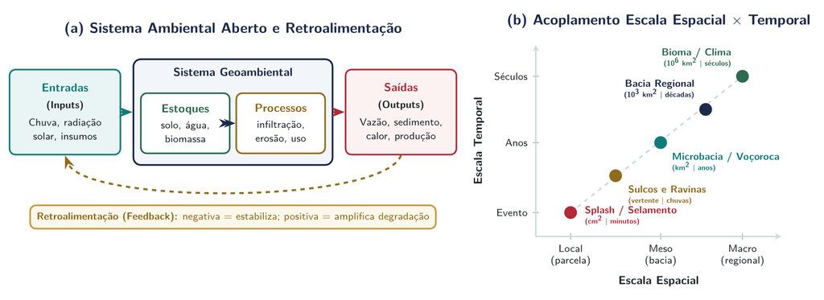

Sistema ambiental aberto com entradas, estoques, processos, saídas e retroalimentação, acoplado à relação entre escala espacial e escala temporal.

Sistema ambiental aberto (a) e acoplamento escala espacial × temporal (b) Elaboração própria (TikZ) · retroalimentação negativa estabiliza o sistema; positiva amplifica a degradação

Processos de detalhe (*splash*, selamento em $\text{cm}^2$/minutos) encadeiam-se com bacias regionais ($10^3\text{ km}^2$/décadas) e biomas ($10^6\text{ km}^2$/séculos): o diagnóstico precisa manter coerência entre ambos os eixos.

## Método Da Abordagem Setorial à Síntese Interdisciplinar

Armadilha metodológica O Erro Clássico do “Diagnóstico Gaveta”

Muitos estudos fracassam por operar em **justaposição multidisciplinar**:

- O geólogo escreve o capítulo de litologia;
- O pedólogo descreve perfis de solo isoladamente;
- O biólogo lista espécies de flora e fauna;
- O sociólogo tabula dados do IBGE;
- **Resultado:** capítulos estanques que não explicam a dinâmica territorial.

Síntese geográfica integrada Geoecologia (Tricart, 1977; Rodriguez et al., 2017; Ross, 2006)

O Geógrafo cruza os processos causais:

- **Litologia e estrutura** condicionam relevo e potencial hidrogeológico;
- **Relevo e clima** comandam hidrodinâmica e solos na vertente (catena);
- **Solo e água** sustentam a vegetação e definem a aptidão agrícola;
- **Uso da terra e estrutura fundiária/urbana** alteram a estabilidade ecodinâmica e geram riscos.

# Escala Espacial e Temporal na Análise Ambiental

## Escalas Distinção Epistemológica Fundamental

Escala Cartográfica (Matemática) Relação métrica mapa–terreno ($d / D$)

Expressa como fração ($1:250.000$, $1:50.000$, $1:2.000$):

- **Escala Pequena** ($1:1.000.000$): denominador grande → grande área, **baixo nível de detalhe**.
- **Escala Grande** ($1:2.000$): denominador pequeno → pequena área, **alto nível de detalhe**.

Escala Geográfica (Conceitual) Iná Elias de Castro (1995)

Recorte espacial que confere visibilidade e sentido explicativo ao fenômeno.

Mudar de escala não é apenas “dar zoom”: **quando a escala muda, mudam as variáveis dominantes e a própria natureza do processo observado**.

A escala de representação cartográfica (IBGE, 2018) só tem rigor técnico quando corresponde à escala geográfica dos processos modelados.

## Escalas Escala Temporal e Defasagem de Processos

| Processo Ambiental | Escala Temporal Típica | Implicação no Diagnóstico |
| --- | --- | --- |
| **Intemperismo e formação de $1\text{ cm}$ de Latossolo** | $10^2$ a $10^3$ anos | Perda de solo por erosão severa é **irreversível** na escala humana. |
| **Sucessão ecológica secundária florestal** | $20$ a $80$ anos | Metas de restauração em PRAD exigem monitoramento plurianual. |
| **Tempo de Retorno ($TR$) de cheias extremas** | $25$, $50$ ou $100$ anos | Séries curtas (1–2 anos) não capturam o risco real de inundação. |
| **Pulso de escoamento e turbidez em tempestade** | Minutos a horas | Exige monitoramento hidrossedimentológico em eventos chuvosos. |

A defasagem entre o tempo dos processos biofísicos e o tempo das decisões administrativas exige séries históricas compatíveis e limiares preventivos.

## Escalas Escolha da escala e qualidade da base

| Finalidade | Escalas indicativas | Verificação indispensável |
| --- | --- | --- |
| **Síntese regional / ZEE** | $1:250.000$ a $1:100.000$ | Generalização de solos, geologia e relevo; diretrizes do instrumento |
| **Sub-bacia / município** | $1:50.000$ a $1:25.000$ | Rede de drenagem, limites das unidades e campo |
| **Encosta / intervenção** | $1:10.000$ a $1:2.000$ | Topografia, material, ocupação e processos ativos |
| **Projeto / monitoramento** | Conforme objetivo e precisão | Referência geodésica e controle independente |

As faixas são exemplos de planejamento (de $1:250.000$ no ZEE até $1:1.000$ em projetos/PRAD). **O tamanho do pixel não garante escala cartográfica nem acurácia**: nunca ampliar um mapa regional de solos como levantamento de detalhe.

# Zoneamento Ecológico-Econômico (ZEE)

## ZEE Fundamentos Legais e Metodológicos

Base legal Lei 6.938/81 e Dec. 4.297/2002

Previsto no **Art. 9º, II da Lei 6.938/1981** e regulamentado pelo **Decreto Federal nº 4.297/2002** (alterado pelo Dec. 6.288/2007).

Caráter vinculante Instrumento de organização

Deve ser obrigatoriamente seguido na implantação de planos, obras e atividades públicas e privadas, definindo padrões segundo **vulnerabilidade natural** e **potencialidades socioeconômicas**.

Método no Brasil UTB · Crepani e Ross

Cruza **Vulnerabilidade Natural à Perda de Solo (Crepani et al., 2001)** ou **Fragilidade Ambiental (Ross, 1994)** com o **Potencial Social/Produtivo** de cada Unidade Territorial Básica (UTB).

O ZEE traduz a análise integrada em regras territoriais diferenciadas por unidade homogênea de paisagem.

## ZEE Tipologia Clássica de Zonas no ZEE

| Zona | Critério Ambiental e Socioeconômico | Diretriz de Ordenamento |
| --- | --- | --- |
| **1. Zonas Produtivas Consolidadas (ZPC)** | Baixa vulnerabilidade natural associada a infraestrutura produtiva instalada | Adensamento e intensificação sustentável com boas práticas de manejo |
| **2. Zonas de Uso Sustentável (ZUS)** | Vulnerabilidade natural média e potencial produtivo moderado | Atividades condicionadas a práticas conservacionistas de solo e água e respeito a APP/RL |
| **3. Zonas de Recuperação Ambiental (ZRA)** | Áreas com degradação avançada, erosão severa ou conflito de uso | Prioridade para PRAD, restauração florestal e reconversão produtiva |
| **4. Zonas de Proteção e Conservação (ZPCo)** | Unidades de Conservação, APPs, nascentes e áreas de alta fragilidade | Regras de uso e proteção próprias de cada categoria e instrumento legal |

# Análise Ambiental Urbana

## Urbano A Cidade como Sistema Socioecológico Modificado

Especificidade urbana Por que exige abordagem própria?

Asfalto, concreto e edificações alteram o balanço de radiação, a infiltração e a estabilidade de encostas. Em alta densidade, falhas pontuais de drenagem ou cortes em taludes atingem grande contingente populacional.

Articulação necessária Clima, água, risco e lei

Integrar climatologia urbana, hidrologia de microbacias urbanizadas, cartografia de risco geotécnico e instrumentos do Estatuto da Cidade.

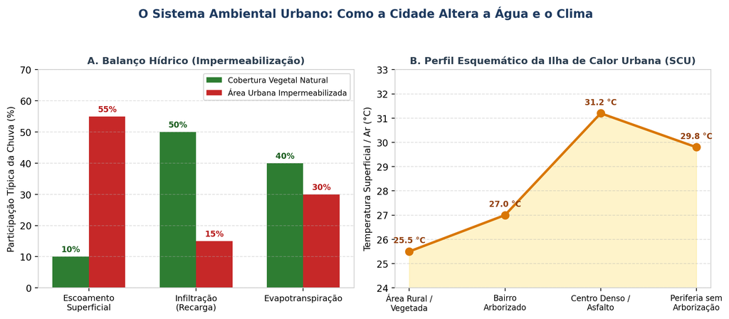

Alteração do balanço hídrico e formação da Ilha de Calor Urbana (SCU) pela impermeabilização e substituição de cobertura vegetal.

Alteração do balanço hídrico (A) e perfil da Ilha de Calor Urbana — SCU (B) Impermeabilização eleva o escoamento superficial (10% → 55%) e reduz a recarga (50% → 15%)

## Urbano Processos Críticos no Ambiente Urbano

01 · Hidrologia Impermeabilização generalizada

Reduz a infiltração direta, altera recarga e escoamento conforme ocupação e rede de drenagem e antecipa o pico de cheia nos fundos de vale (**alagamentos e inundações bruscas**).

02 · Geomorfologia Encostas e canais modificados

Cortes verticais sem contenção + águas servidas geram **escorregamentos (R3/R4)**. Retificação e aterramento de planícies e lagoas (ex.: nascentes e lagoas em **Feira de Santana – BA**) agravam cheias.

03 · Climatologia Ilhas de Calor (SCU — Monteiro, 1976)

Asfalto/concreto (baixo albedo e alta capacidade térmica) + cânions urbanos produzem anomalias térmicas cuja magnitude varia com horário, estação, cobertura, morfologia e método.

## Urbano Instrumentos Urbanísticos e Ambientais

**Lei 10.257/2001 (Estatuto da Cidade) e Lei 12.608/2012:** Plano Diretor Municipal obrigatório para cidades com $> 20\text{ mil hab.}$ ou incluídas no cadastro nacional de áreas com risco de desastres.

Ordenamento territorial Macrozoneamento e ZEIS

Definição de **macrozoneamento urbano-ambiental** e de **ZEIS** (Zonas Especiais de Interesse Social) obrigatoriamente fora de áreas de risco **R4**.

Infraestrutura verde Permeabilidade e Drenagem Sustentável

**Taxa de Permeabilidade Mínima do Lote** e dispositivos de **Drenagem Urbana Sustentável** (*jardins de chuva, trincheiras de infiltração, bacias de detenção, pavimentos permeáveis*).

Arts. 36 a 38 · Lei 10.257/2001 Estudo de Impacto de Vizinhança (EIV)

Avalia adensamento populacional, ventilação/iluminação, tráfego, drenagem pluvial e sobrecarga na infraestrutura urbana instalada.

# Roteiro Prático, Síntese e Referências

## Roteiro Um roteiro de integração para o trabalho final

Fases 1 a 4 Da organização à integração

1. **Organização:** pergunta, equipe, área, escala e produtos.
2. **Inventário:** bases físicas, biológicas e sociais, com datas e fontes.
3. **Análise:** processos, relações causais e limitações.
4. **Integração:** unidades e conexões entre vertente, canal e ocupação.

Fases 5 a 7 Do diagnóstico à proposição

5. **Diagnóstico:** problemas, potencialidades e conflitos de uso.
6. **Prognóstico:** cenários com e sem intervenção.
7. **Proposição:** prioridades, responsáveis, indicadores e revisão.

Roteiro didático adaptado da análise integrada e da Geoecologia das Paisagens. As etapas se retroalimentam; a síntese pode exigir novo levantamento em campo.

## Oficina Oficina: o que muda quando a escala muda?

Comparação prática Mapa regional de solos × Topossequência de campo

Compare as duas representações e responda:

- Que informações foram generalizadas na legenda regional?
- O polígono regional permite localizar uma passagem entre horizontes ou uma surgência?
- Qual evidência sustenta a decisão de zonear, monitorar ou projetar?

Produto da atividade Entrega esperada

Quadro comparativo contendo para cada fonte utilizada:

1. **Dado** analisado;
2. **Escala original** do levantamento;
3. **Limitação** técnica identificada;
4. **Uso aceitável** no relatório técnico.

## Síntese Síntese Operacional

**01 · Unidades Geoambientais:** a **Análise Ambiental Integrada** supera o inventário setorial ao articular processos morfodinâmicos, bióticos e socioeconômicos (base para **Tricart**, **Ross** e **Crepani**, aprofundados na **Aula 9.1**).

**02 · Compatibilidade escalar:** a escolha da **escala cartográfica e geográfica** deve ser estritamente compatível com o instrumento ($1:250.000$ no ZEE regional vs. $1:2.000$ no PRAD e na Carta de Risco Urbano).

**03 · Meio urbano integrado:** o Geógrafo articula o **Sistema Clima Urbano (SCU)**, a **hidrologia de bacias urbanizadas** e as diretrizes do **Estatuto da Cidade (Lei 10.257/2001)**.

## Referências Referências Bibliográficas

Marco legal e institucional Legislação

- BRASIL. **Lei nº 10.257, de 10 de julho de 2001** (Estatuto da Cidade).
- BRASIL. **Decreto nº 4.297, de 10 de julho de 2002** (Regulamenta o Zoneamento Ecológico-Econômico — ZEE).
- IBGE. **Manual Técnico de Uso da Terra / Normas Cartográficas**. Rio de Janeiro: IBGE, 2018.

Literatura teórico-metodológica Bibliografia fundamental

- CASTRO, I. E. O problema da escala. In: CASTRO, I. E.; GOMES, P. C. C.; CORRÊA, R. L. (Orgs.). **Geografia: Conceitos e Temas**. Rio de Janeiro: Bertrand Brasil, 1995. p. 117–140.
- CHRISTOFOLETTI, A. **Modelagem de Sistemas Ambientais**. São Paulo: Edgard Blücher, 1999.
- RODRIGUEZ, J. M. M.; SILVA, E. V.; CAVALCANTI, A. P. B. **Geoecologia das Paisagens: uma visão geossistêmica da análise ambiental**. 5. ed. Fortaleza: Edições UFC, 2017.
- ROSS, J. L. S. **Ecogeografia do Brasil: subsídios para o planejamento ambiental**. São Paulo: Oficina de Textos, 2006.